# Project 1 Checkpoint 3

```r
library(httr)
library(tidyjson)
library(jsonlite)
library(tidyverse)
library(glue)
```

##Gathering GDP Data I used the API listed for the Country GDP over a set number of years, I built a function to iterate over all of the country 3 letter alpha codes to pull all of their GDP data. After I had all of the GDP data for the countries in my democracy dataset, I used a bind rows by country_code as the id to create one large data frame.

```r
democracy_data <- readr::read_csv('https://raw.githubusercontent.com/rfordatascience/tidytuesday/main/data/2024/2024-11-05/democracy_data.csv')
# Importing the data

country_code <- democracy_data |>
    distinct(
        country_code
        ) |>
    pull(country_code)
# Extracting the Country Codes

 usa_df <- democracy_data |>
    filter(country_code == "USA")
 # Taking only USA
```

```r
get_gdp <- function(country, key = my_key){

    url <- glue("https://api.api-ninjas.com/v1/gdp?country={country};X-Api-Key={key}")
    # My Url for API GDP data

    my_data <- safely(fromJSON)(url)
    # Safely to grab data regardless errors

    if (is.null(my_data$result)) {
        return(NA)
    } else {
        return(my_data$result)
    }
    # Procaution against missing Countries.

}
get_gdp("USA")
```

```
Error:
! Failed to evaluate glue component {key}
Caused by error:
! object 'my_key' not found
```

```r
# Test

country_gdp <- map(country_code, get_gdp)
```

[output not shown]

```r
# All data for each distinct country in my Democracy data set
```

```r
country_gdp_df <- country_gdp |>
    setNames(country_code
             ) |>
    bind_rows(
        .id = "country_code"
    )
```

```
Error:
! object 'country_gdp' not found
```

##Gathing Unemployment Datas I used the API listed for the Unemployment Data over a set number of years, I built a function to iterate over all of the country 3 letter alpha codes to pull all of their GDP data. After I had all of the Unemployement data for the countries in my democracy dataset, I used a bind rows by country_code as the id to create one large data frame.

```r
country = "CAN"
baseurl = "https://api.api-ninjas.com/v1/unemployment?country="
can_url = glue("{baseurl}{country};X-Api-Key={key}")
```

```
Error:
! Failed to evaluate glue component {key}
Caused by error:
! object 'key' not found
```

```r
can_data = fromJSON(can_url)
```

```
Error:
! object 'can_url' not found
```

```r
funky_Employ <- function(country_code){
  baseurl = "https://api.api-ninjas.com/v1/unemployment?country="
  url = glue("{baseurl}{country_code};X-Api-Key={key}")
  employ_data = fromJSON(url)
  return(employ_data)
}
can_data <- funky_Employ(country)
```

```
Error:
! Failed to evaluate glue component {key}
Caused by error:
! object 'key' not found
```

```r
democracy_data <- readr::read_csv('https://raw.githubusercontent.com/rfordatascience/tidytuesday/main/data/2024/2024-11-05/democracy_data.csv')
democ_countrycode <- democracy_data |>
  select(country_code) |>
  distinct(country_code) |>
  pull(country_code)
```

```r
employ <- map(democ_countrycode, funky_Employ)
```

[output not shown]

```r
#employ2 <- map_dfr(democ_countrycode, funky_Employ)
write.csv(employ2, "employ2.csv", row.names = FALSE)
```

```
Error:
! object 'employ2' not found
```

```r
employ <- read.csv("employ2.csv")
#4543 rows
employ |>
  distinct(country_code) |>
  count()
```

```
Error in `distinct()`:
! Must use existing variables.
✖ `country_code` not found in `.data`.
```

```r
#110 countries in this

names(employ) <- c("country_code", "year", "unemployment_rate")

#check for duplicate countries & years
democracy_data |>
  count(country_code, year) |>
  filter(n > 1)
```

[output not shown]

```
# A tibble: 0 × 3
# ℹ 3 variables: country_code <chr>, year <dbl>, n <int>
```

```r
employ |>
  add_count(country_code, year) |>
  filter(n > 1)
```

```
   country_code year unemployment_rate n
1           IRN 1990              14.2 2
2           IRN 1991              10.0 2
3           IRN 1992              10.0 2
4           IRN 1993              10.0 2
5           IRN 1994              10.0 2
6           IRN 1995              10.0 2
7           IRN 1996               9.1 2
8           IRN 1997              11.9 2
9           IRN 1998              13.6 2
10          IRN 1999              15.8 2
11          IRN 2000              16.0 2
12          IRN 2001              16.6 2
13          IRN 2002              12.2 2
14          IRN 2003              11.3 2
```

[output cut: 66 more lines]

```r
#shows that there are 40 country code duplicates
employ<- employ |>
  distinct()

employ_democracy_data <- democracy_data |>
  left_join(employ, by = c("country_code", "year"))

employ_democracy_data |>
  summarize(missing_unemployment = sum(is.na(unemployment_rate)))
```

```
# A tibble: 1 × 1
  missing_unemployment
                 <int>
1                11195
```

```r
#11195 missing values which makes sense because this api only has data for 110 countries and limited years

write.csv(employ_democracy_data, "employ_democracy_data.csv", row.names = FALSE)
```

##All the Data Combind

```r
# Democracy data
democracy_data<-readr::read_csv('https://raw.githubusercontent.com/rfordatascience/tidytuesday/main/data/2024/2024-11-05/democracy_data.csv')
# GDP data
gdpData <- read.csv("Country_GDP.csv")

# Employment data
employData<-read.csv("employ2.csv")

#Combining the two data sets found through API's
combined <- left_join(
  gdpData,
  employData,
  by = c("year", "country"),
  relationship = "many-to-many"
)
# Combining with orginal democracy_data
masterSet<-left_join(democracy_data, combined, by=c('country_code','year'))

write_csv(masterSet,file="masterSet.csv")
```

```r
masterSet<-read.csv("masterSet.csv")
```

##Visualizing the relationship between GDP growth and if a country is a democracy, over time.

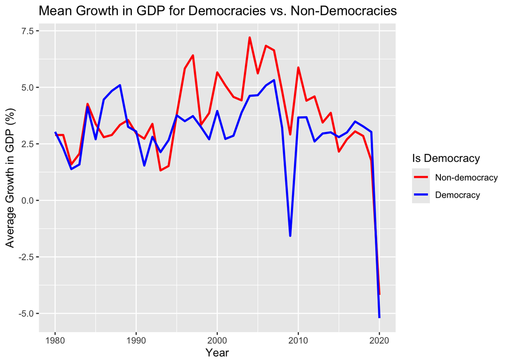

```r
aveGrowth <- masterSet %>%
  group_by(year, is_democracy) %>%
  summarise(mean_growth = mean(gdp_growth, na.rm = TRUE), .groups = "drop") %>%
  filter(!is.na(mean_growth), !is.na(is_democracy))

ggplot(aveGrowth, aes(x=year,y=mean_growth,color=is_democracy))+
  geom_line(linewidth = 1)+
  labs(x="Year",
       y="Average Growth in GDP (%)",
       title="Mean Growth in GDP for Democracies vs. Non-Democracies",
       color="Is Democracy")+
  scale_color_manual(
  values = c("TRUE" = "blue", "FALSE" = "red"),
  labels = c("FALSE" = "Non-democracy", "TRUE" = "Democracy")
)
```

##Visualizing the change in unemployment rate over time for countries that are communist vs. are not communist.

```r
aveRate<- masterSet %>%
  group_by(year, is_communist) %>%
  summarise(mean_rate = mean(unemployment_rate,na.rm=TRUE, .groups='drop')) %>%
  filter(!is.na(mean_rate), !is.na(year))
```

[output not shown]

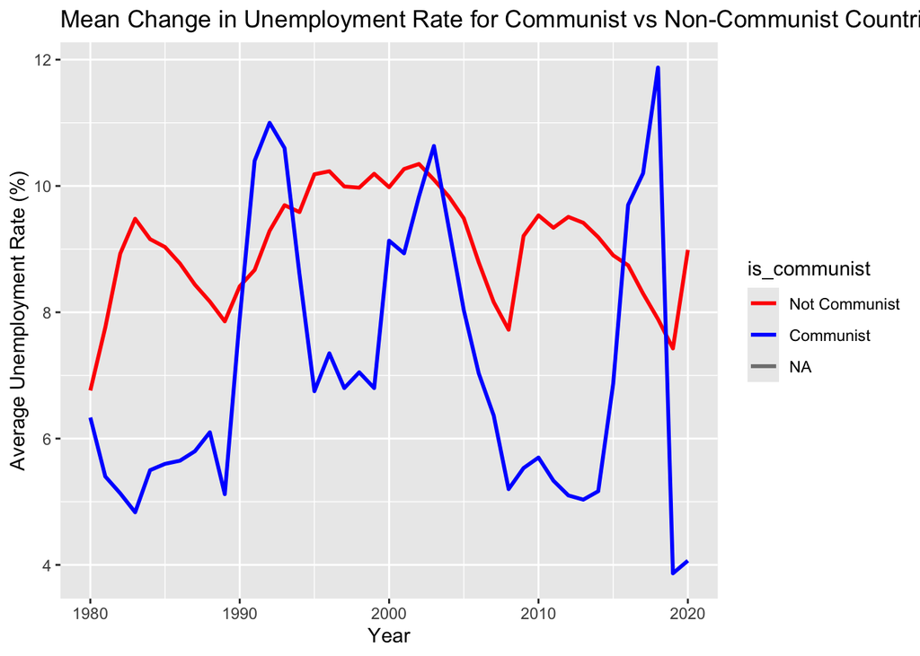

```r
ggplot(aveRate, aes(x=year,y=mean_rate,color=is_communist))+
  geom_line(linewidth=1)+
  labs(x ="Year",y ="Average Unemployment Rate (%)", title = "Mean Change in Unemployment Rate for Communist vs Non-Communist Countries")+
  scale_color_manual(
  values = c("TRUE" = "blue", "FALSE" = "red"),
  labels = c("FALSE" = "Not Communist", "TRUE" = "Communist")
)
```